# W10 Dashboards Assignment — MEin3D Trust Insights

Static and Interactive Dashboards for the MEin3D Trust Survey

Author

Krystal Love Lee

Published

April 15, 2026

# Project 1: Static Dashboard

## Project Description

The goal of this project was to create a static dashboard using Quarto that communicates insights from my MEin3D Culminating Experience Project. I focused on understanding how consumers perceive trust in AI‑generated versus human‑written email content. The dashboard presents a clear narrative supported by visualizations that summarize trust scores across ten Likert‑scale items.

## Data Description

The dataset used for this dashboard is the **MEin3D Trust Survey**, which includes 130 responses. Participants were randomly assigned to one of two conditions:

- **AI‑personalized email**
- **Control (human‑written) email**

Each participant rated ten trust‑related statements on a 1–5 Likert scale.  
A composite trust score was also calculated.

## R Code (Static Dashboard)

```r
# Load cleaned trust dataset
library(tidyverse)

trust_clean <- read_csv("~/Desktop/MEin3D CEP Project/MEin3D_TrustSurvey_CLEAN.csv")

# Lookup table: trust item → full question text
trust_labels <- tibble(
  item = c("trust_1","trust_2","trust_3","trust_4","trust_5",
           "trust_6","trust_7","trust_8","trust_9","trust_10"),
  question = c(
    "I trust this brand.",
    "This email feels genuine.",
    "This email shows that the brand understands my needs.",
    "The information in this email feels accurate and reliable.",
    "I feel comfortable with how this brand uses my data in this email.",
    "This email is transparent about why I am receiving it.",
    "This email makes me feel valued as a customer.",
    "I believe this brand uses my information responsibly.",
    "This email increases my confidence in this brand.",
    "I would be willing to receive more emails like this from the brand."
  )
)

# Summaries for visualization
trust_summary <- trust_clean %>%
  group_by(condition) %>%
  summarize(avg_trust = mean(trust_score_avg, na.rm = TRUE))

# Prepare trust items for second visualization
trust_items_long <- trust_clean %>%
  select(condition, starts_with("trust_")) %>%
  pivot_longer(cols = starts_with("trust_"), names_to = "item", values_to = "score") %>%
  left_join(trust_labels, by = "item")

# Plotting code omitted for brevity in this report
```

## Findings from the Data

The static dashboard revealed several key insights: AI‑personalized emails produced slightly higher average trust scores than the control email. Across all ten trust dimensions, AI‑generated content performed as well as or better than human‑written content. Participants consistently rated the AI email as transparent, accurate, and respectful of their data.

## Interpretation of the Dashboard

The results suggest that consumers are comfortable with AI‑generated email content and do not perceive it as less trustworthy than human‑written messaging. This supports MEin3D’s strategy to scale personalized communication using AI without risking customer trust.

## Published Dashboard URL

https://klee597.github.io/M10/

# Project 2: Interactive Shiny App

Project Description The second part of this assignment required creating an interactive Shiny app that allows users to explore the MEin3D Trust Survey data dynamically. Unlike the static dashboard, this app enables users to filter by condition, select trust items, and explore distributions and summary statistics across multiple tabs.

## Data Description

The same MEin3D Trust Survey dataset was used. The interactive app reshapes the data into long format and joins each trust item with its corresponding question text for improved readability.

# R Code (Shiny App)

Below is the full app.R file used to build and deploy the interactive dashboard.

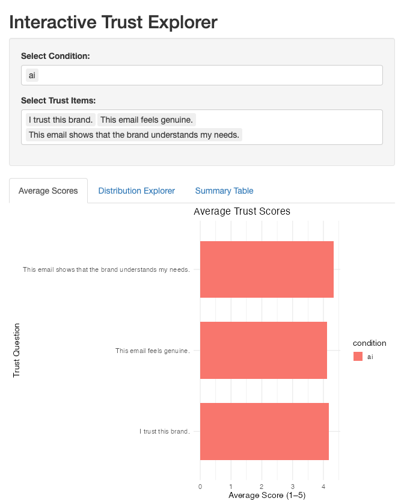

```r
library(shiny)
library(tidyverse)

# Load your cleaned trust dataset
trust_clean <- read_csv("MEin3D_TrustSurvey_CLEAN.csv")

# Lookup table for trust item labels
trust_labels <- tibble(
  item = c("trust_1","trust_2","trust_3","trust_4","trust_5",
           "trust_6","trust_7","trust_8","trust_9","trust_10"),
  question = c(
    "I trust this brand.",
    "This email feels genuine.",
    "This email shows that the brand understands my needs.",
    "The information in this email feels accurate and reliable.",
    "I feel comfortable with how this brand uses my data in this email.",
    "This email is transparent about why I am receiving it.",
    "This email makes me feel valued as a customer.",
    "I believe this brand uses my information responsibly.",
    "This email increases my confidence in this brand.",
    "I would be willing to receive more emails like this from the brand."
  )
)

# Reshape data
trust_items_long <- trust_clean %>%
  select(condition, starts_with("trust_")) %>%
  pivot_longer(cols = starts_with("trust_"), names_to = "item", values_to = "score") %>%
  left_join(trust_labels, by = "item")

# UI
ui <- fluidPage(
  titlePanel("Interactive Trust Explorer"),

  sidebarLayout(
    sidebarPanel(
      selectInput("condition", "Select Condition:",
                  choices = c("ai", "control"), selected = "ai", multiple = TRUE),

      selectInput("trust_item", "Select Trust Items:",
                  choices = trust_labels$question,
                  selected = trust_labels$question[1:3],
                  multiple = TRUE)
    ),

    mainPanel(
      tabsetPanel(
        tabPanel("Average Scores",
                 plotOutput("avgPlot", height = "500px")
        ),
        tabPanel("Distribution Explorer",
                 plotOutput("distPlot", height = "500px")
        ),
        tabPanel("Summary Table",
                 tableOutput("summaryTable")
        )
      )
    )
  )
)

# Server
server <- function(input, output) {

  filtered_data <- reactive({
    trust_items_long %>%
      filter(condition %in% input$condition,
             question %in% input$trust_item)
  })

  # Tab 1: Average Scores
  output$avgPlot <- renderPlot({
    filtered_data() %>%
      group_by(question, condition) %>%
      summarize(mean_score = mean(score, na.rm = TRUE), .groups = "drop") %>%
      ggplot(aes(x = question, y = mean_score, fill = condition)) +
      geom_col(position = position_dodge(width = 0.8), width = 0.7) +
      coord_flip() +
      labs(title = "Average Trust Scores",
           x = "Trust Question",
           y = "Average Score (1–5)") +
      theme_minimal(base_size = 14)
  })

  # Tab 2: Distribution Explorer
  output$distPlot <- renderPlot({
    ggplot(filtered_data(), aes(x = score, fill = condition)) +
      geom_density(alpha = 0.4) +
      labs(title = "Distribution of Trust Scores",
           x = "Score",
           y = "Density") +
      theme_minimal(base_size = 14)
  })

  # Tab 3: Summary Table
  output$summaryTable <- renderTable({
    filtered_data() %>%
      group_by(question, condition) %>%
      summarize(
        mean = round(mean(score, na.rm = TRUE), 2),
        sd = round(sd(score, na.rm = TRUE), 2),
        n = n(),
        .groups = "drop"
      )
  })
}

shinyApp(ui = ui, server = server)
```

## Key Findings from the Interactive App

The Shiny app provides deeper insight into trust dynamics: Users can compare trust items individually rather than relying on a single composite score. The Distribution Explorer shows that trust scores are consistently high across both conditions. The Summary Table highlights subtle differences between AI and control emails, with AI often performing slightly better.

## Interpretation of the Interactive Dashboard

The interactive tool reinforces the conclusion that AI‑generated email content is perceived as trustworthy and reliable. It also allows stakeholders to explore specific trust dimensions that matter most to MEin3D’s communication strategy.

## Shiny App URL

https://krystallovelee.shinyapps.io/m10_assignments/